# FordGoBikes Analysis

## by Olaoluwa Idowu

## Investigation Overview

This analysis is to examine FordGoBikes data based on Gender, User type and bike sharing.

key Insights -

> The male gender take more trips than other genders. They make up 74% of the total trips

> Only subscriber user have the bike sharing option.

## Dataset Overview

> This data set includes information about individual rides made in a bike-sharing system covering the greater San Francisco Bay area

## Distribution of Ages

> The distribution of ages is positively skewed. Majority of the riders are young

> There are more riders between the ages of 20 and 60. There is a higher count of riders between the ages of 20 to 40.

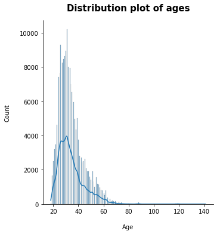

## Proportion of trips based on gender

> The male gender has the highest count of trips. They make up 74.59% of the total trips

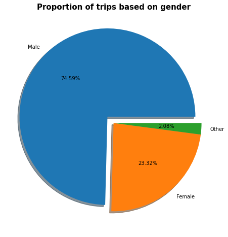

## Proportion of trips based on user

> The subscriber users have higher number of trips than the customer user type. 90.5% of the trips are by subscribers

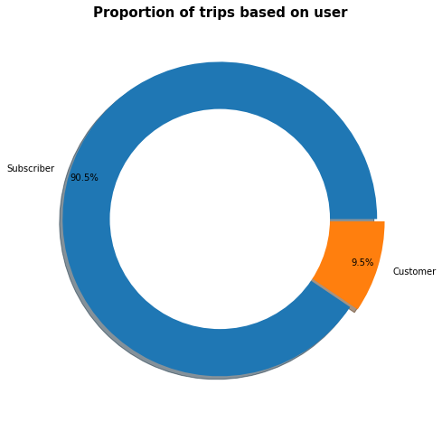

# Bike sharing based on user type

> Only subscriber user have the bike sharing option. No record of bike sharing for customers

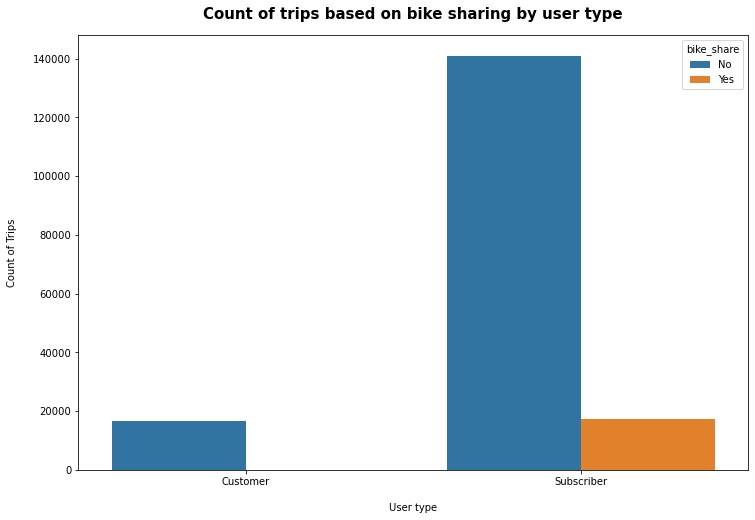